# circular-task-assignment

Circular task analysis

01 November 2025, 16:12:51

by Denis Mottet (and Copilot)

The task is described in [Fauviaux et al. (2021)](https://hal.science/hal-03834500). The data was recorded with the MouseReMoCo software.

To understand how the data was recorded, you are invited to play with MouseReMoCo on you own computer. Once you really understand how the task works, what is recorded and how to interpret the content of the data files, you can start working on the codding part of this assignment.

**NOTE:** The coding part of this assignment is not the difficult part. The difficult part is to understand how the data was recorded and how to interpret the content of the data files. So please, take your time to understand the task, carefully read the documentation in the GitHub repository, and explore the task and the data generated on your own computer before starting coding.

Your mission is to work in teams of 3 students to deliver a public GitHub repository containing your circular task analysis.

In this repository, you will:

- Reproduce the graphics below, using the data files provided in the assignment (`001MoDe_R1.csv` and `001MoDe_R1.marker.csv`).
- Re-compute the values in the table at the end of `001MoDe_R1.marker.csv` file using your own code to analyze the data in `001MoDe_R1.csv`.
- Run your code on at least one data file that you generated yourself with *MouseReMoCo*.
- Write a brief report (1 to 2 pages) explaining the most interesting difficulties you encountered and resolved, and how you verified that your results were correct.
- Explain who was responsible for what within the team and how you organized your teamwork.

# Advice for managing your GitHub repository

Take your time to re-explore the Python-for-HMS-Template repository and understand its structure, components, and how it can be utilized for your specific needs.

In each team, decide on one member to manage the project. The manager will be responsible for creating the GitHub repository and ensuring that all team members have access. The manager will also oversee the integration of contributions from all team members, and will be the **only one to merge** pull requests (i.e., be the assignee).

Each team member should create a new branch for their work. Once a member has completed their analysis or coding task, they should create a pull request to merge their branch into the main branch, asking for the review of the other team members.

Avoid working in parallel on the same files to minimize merge conflicts. If conflicts do arise, the manager will handle them during the merging process.

# Code snippets to get you started

```python
# imports (this is all you need for this assignment - please, do not import anything else)
import numpy as np
import matplotlib.pyplot as plt
import os

# very useful for zoomable plots in Jupyter notebooks
%matplotlib widget

# import pandas as pd # we do not use pandas here
```

```python
# if the present working directory is the directory of this file, change the path to the project root
if os.getcwd().endswith("notebooks"):
    os.chdir("..")
```

# Expected results

Below are the expected results for the provided data files (`001MoDe_R1.csv` and `001MoDe_R1.markers.csv`).

```
Header line information in 'data/001MoDe_R1.csv':
  screenWidth: 1104.0
  screenHeight: 661.0
  cornerX: 302.0
  cornerY: 80.0
  centerX: 552.0
  centerY: 330.0
  externalRadius: 250.0
  internalRadius: 170.0
  borderRadius: 1.0
  cursorRadius: 16.0
  indexOfDifficulty: 28.00696429476858
  taskRadius: 209.5
  taskTolerance: 47.0
  borderColor: java.awt.Color[r=255,g=255,b=255]
  backgroundColor: java.awt.Color[r=0,g=0,b=0]
  cursorColorRecord: java.awt.Color[r=255,g=0,b=0]
  cursorColorWait: java.awt.Color[r=255,g=255,b=0]
  autoStart: 3600.0
  cycleMaxNumber: 6.0
  cycleDuration: 20.0
  software: LSL-mouse
  version: 1.2.0rc5
  task: CircularTarget
  isWithLSL: false
```

```
Markers in 'data/001MoDe_R1.marker.csv':
1616776712325: KeyTyped=32 DoCycleChange
1616776712331: DoCycleChange:DoStartCycleTimedSequence
1616776712333: DoCycleChange:DoRecord RecordDone=0 PauseDone=0 ToDo=6
1616776732336: DoCycleChange:DoPause RecordDone=1 PauseDone=0 ToDo=6
1616776752340: DoCycleChange:DoRecord RecordDone=1 PauseDone=1 ToDo=6
1616776772351: DoCycleChange:DoPause RecordDone=2 PauseDone=1 ToDo=6
1616776792372: DoCycleChange:DoRecord RecordDone=2 PauseDone=2 ToDo=6
1616776812386: DoCycleChange:DoPause RecordDone=3 PauseDone=2 ToDo=6
1616776832390: DoCycleChange:DoRecord RecordDone=3 PauseDone=3 ToDo=6
1616776852404: DoCycleChange:DoPause RecordDone=4 PauseDone=3 ToDo=6
1616776872419: DoCycleChange:DoRecord RecordDone=4 PauseDone=4 ToDo=6
1616776892433: DoCycleChange:DoPause RecordDone=5 PauseDone=4 ToDo=6
1616776898364: KeyTyped=113 WINDOW_CLOSING
1616776898367:
    Var , nLaps ,      Re ,      Te ,   error ,  MT/lap , IDe/lap ,      Be ,     IPe ,
   unit ,   lap ,   pixel ,   pixel ,       % ,   s/lap , bit/lap ,  double ,   bit/s ,
 Theory ,  1.00 ,  209.50 ,   47.00 ,    3.88 ,         ,         ,    1.00 ,         ,
 Rec001 ,-10.85 ,  213.87 ,   91.79 ,    3.90 ,    1.84 ,   14.64 ,    1.95 ,    7.94 ,
 Rec002 ,-11.97 ,  209.85 ,   34.46 ,    0.74 ,    1.59 ,   38.27 ,    0.73 ,   24.04 ,
 Rec003 ,-13.26 ,  209.43 ,   42.42 ,    2.81 ,    1.45 ,   31.02 ,    0.90 ,   21.40 ,
 Rec004 ,-12.83 ,  209.46 ,   37.14 ,    0.13 ,    1.49 ,   35.43 ,    0.79 ,   23.72 ,
 Rec005 ,-14.74 ,  210.89 ,   43.88 ,    2.84 ,    1.30 ,   30.20 ,    0.93 ,   23.20 ,
 Rec006 ,  0.00 ,    0.00 ,    0.00 ,     NaN ,     NaN ,     NaN ,    0.00 ,    0.00 ,
```

```
record times (milliseconds since the Unix epoch, 00:00:00 UTC on January 1, 1970):
1616776712333 to 1616776732336 (20.003 s)
1616776752340 to 1616776772351 (20.011 s)
1616776792372 to 1616776812386 (20.014 s)
1616776832390 to 1616776852404 (20.014 s)
1616776872419 to 1616776892433 (20.014 s)
```

```
record times (seconds since the first DoRecord marker):
  0.004 to  20.007 (20.003 s)
 40.011 to  60.022 (20.011 s)
 80.043 to 100.057 (20.014 s)
120.061 to 140.075 (20.014 s)
160.090 to 180.104 (20.014 s)
```

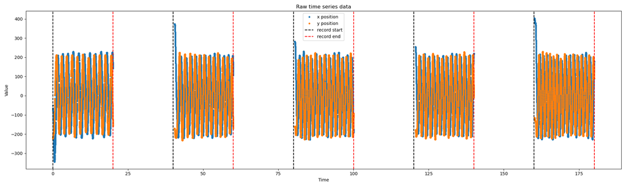

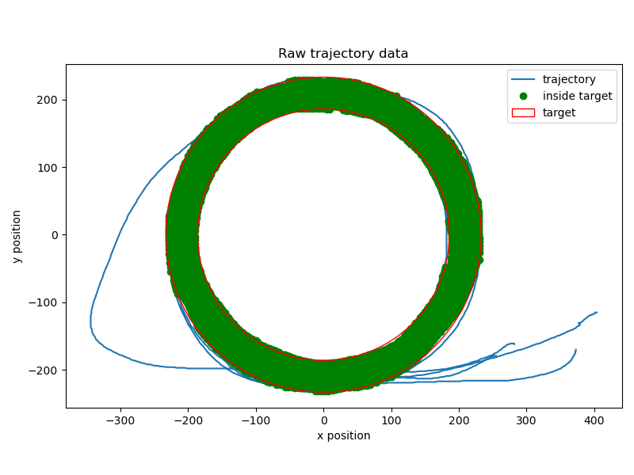

```
Number of records: 5
record 0: 3971 samples from   0.022 to  20.004 s, (19.982s, 198.679 Hz)
record 1: 3898 samples from  40.429 to  60.018 s, (19.589s, 198.938 Hz)
record 2: 3898 samples from  80.371 to 100.050 s, (19.679s, 198.028 Hz)
record 3: 3884 samples from 120.608 to 140.069 s, (19.461s, 199.527 Hz)
record 4: 3936 samples from 160.146 to 180.098 s, (19.952s, 197.223 Hz)
```

```
recomputed statistics for all records:
   Var , nLaps ,      Re ,      Te ,   error ,  MT/lap , IDe/lap ,      Be ,     IPe ,
  unit ,   lap ,   pixel ,   pixel ,       % ,   s/lap , bit/lap ,  double ,   bit/s ,
Theory ,  1.00 ,  209.50 ,   47.00 ,    3.88 ,         ,         ,    1.00 ,         ,
Rec001 , 10.84 ,  213.86 ,   91.78 ,   96.10 ,    1.84 ,   14.64 ,    1.95 ,    7.94 ,
Rec002 , 11.97 ,  209.85 ,   34.45 ,   99.26 ,    1.59 ,   38.27 ,    0.73 ,   24.04 ,
Rec003 , 13.26 ,  209.43 ,   42.42 ,   97.19 ,    1.45 ,   31.02 ,    0.90 ,   21.40 ,
Rec004 , 12.83 ,  209.46 ,   37.14 ,   99.87 ,    1.49 ,   35.44 ,    0.79 ,   23.72 ,
Rec005 , 14.74 ,  210.89 ,   43.88 ,   97.16 ,    1.30 ,   30.20 ,    0.93 ,   23.20 ,
```

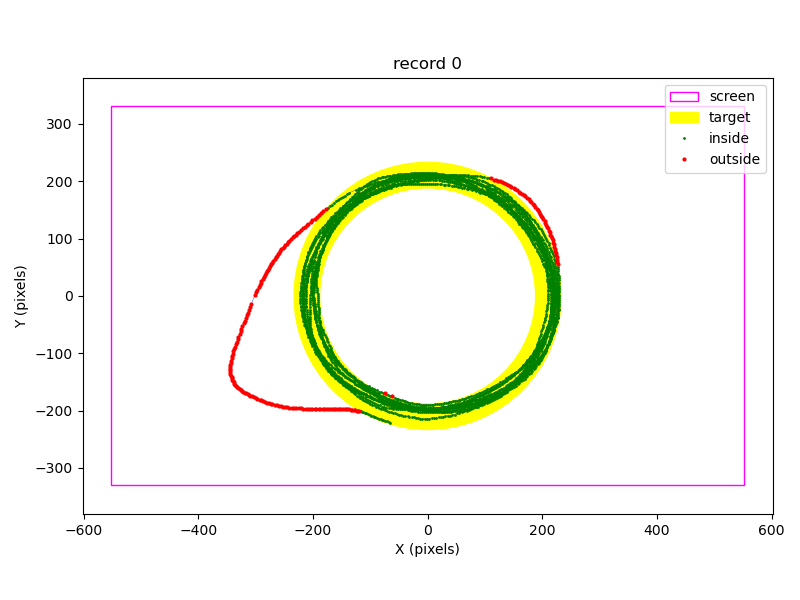

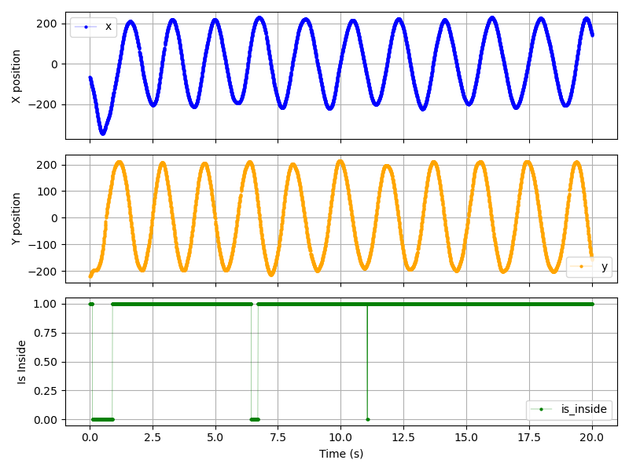

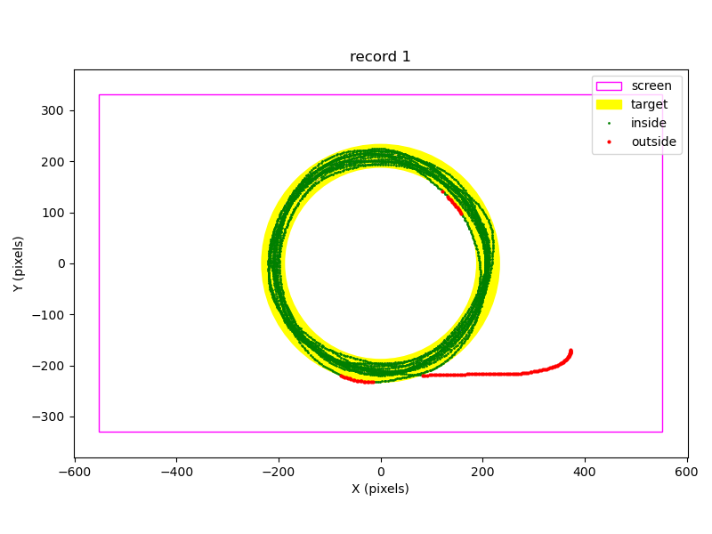

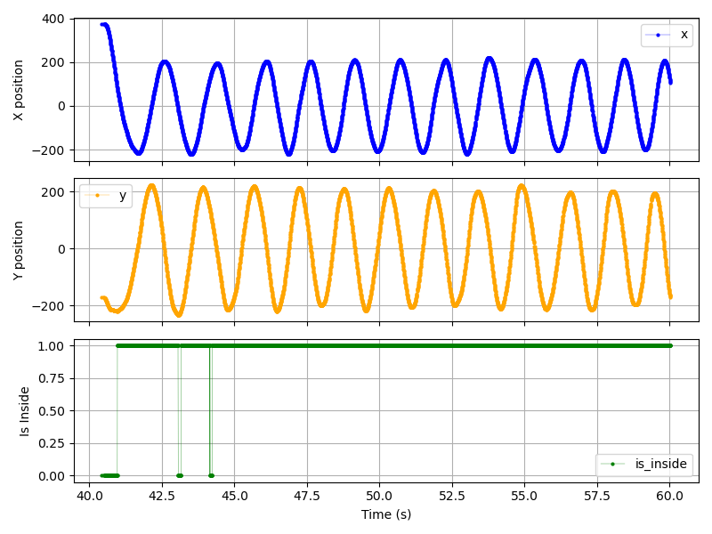

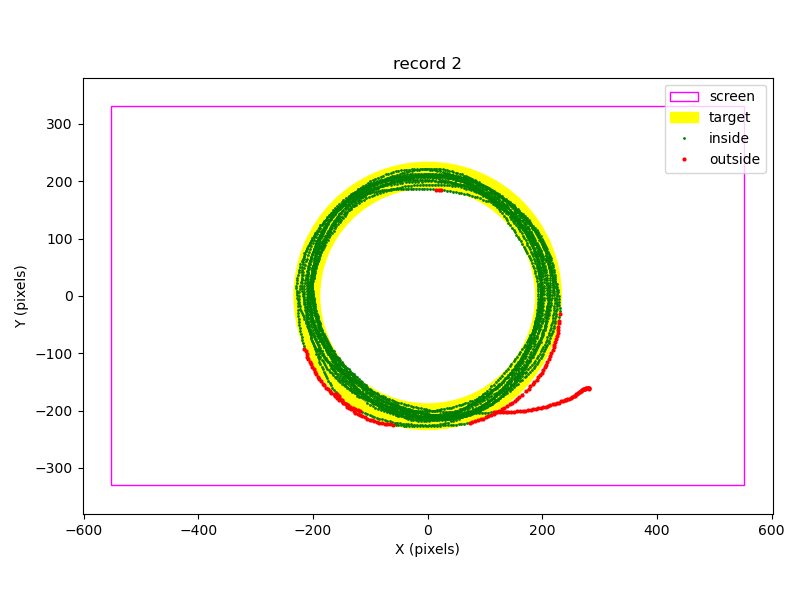

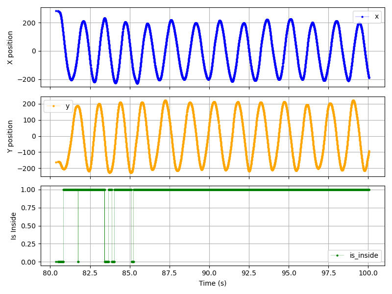

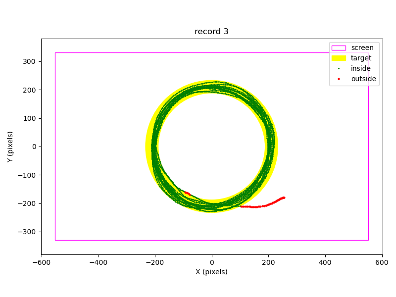

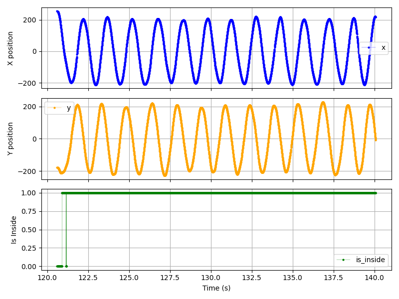

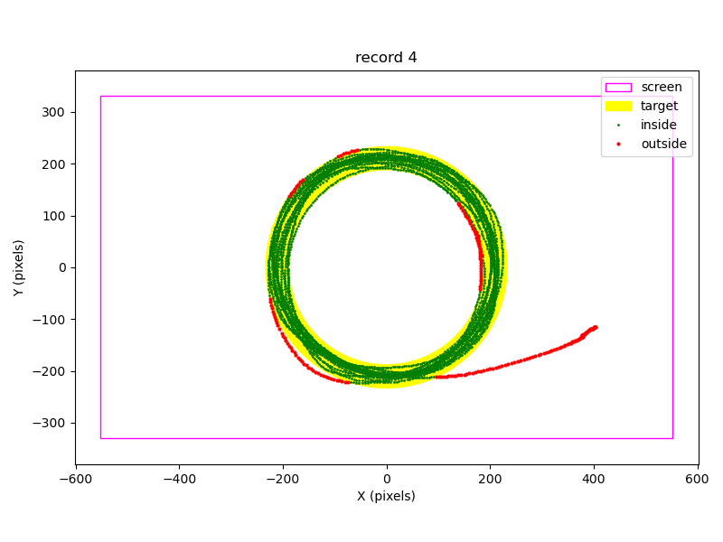

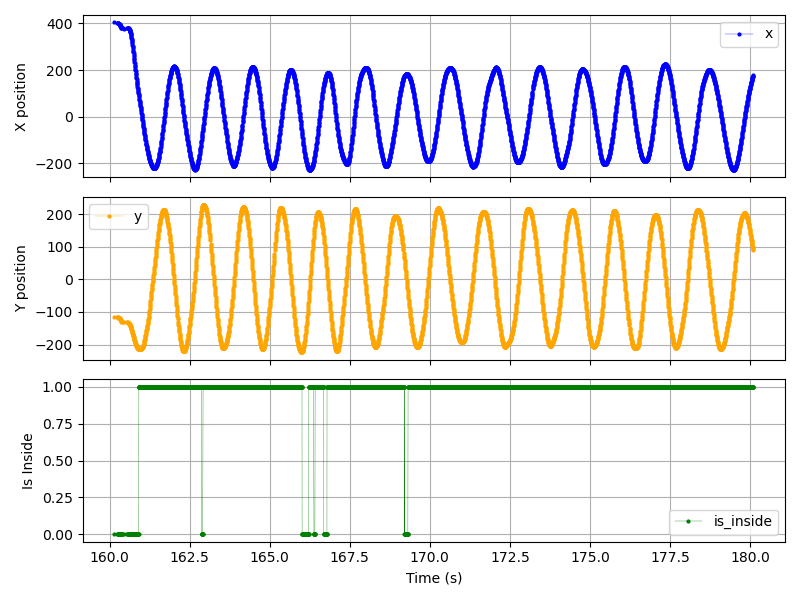

```
Switched to 'inline' backend for HTML export
```